# Homework 2

## Models with `scikit-learn`

### by: Yasshin Lozano

### Loading a data set

We will load in the `digits` data set that comes with **`scikit-learn`**

```python
# ----------- Import `datasets` from `sklearn` -----------
from sklearn import datasets


# Load in the `digits` data
digits = datasets.load_digits()
```

Note that the `datasets` module contains other methods to load and fetch popular reference datasets. You can check a list of available data sets and tools in the [`scikit-learn` website](http://scikit-learn.org/stable/datasets/).

### Exploring the data set

You can access the `digits` data through the attribute `data`. Similarly, you can also access the target values or labels through the `target` attribute and the description through the `DESCR` attribute.

To see which keys you have available to already get to know your data, you can just run `digits.keys()`.

**Execute the code in the cell below**

```python
# ----------- Exploring the dataset	-----------
# Get the keys of the `digits` data
print(digits.keys())

# Print out the data
print(digits.data)

# Print out the target values
print(digits.target)

# Print out the description of the `digits` data
print(digits.DESCR)
```

```
dict_keys(['data', 'target', 'target_names', 'images', 'DESCR'])
[[  0.   0.   5. ...,   0.   0.   0.]
 [  0.   0.   0. ...,  10.   0.   0.]
 [  0.   0.   0. ...,  16.   9.   0.]
 ...,
 [  0.   0.   1. ...,   6.   0.   0.]
 [  0.   0.   2. ...,  12.   0.   0.]
 [  0.   0.  10. ...,  12.   1.   0.]]
[0 1 2 ..., 8 9 8]
Optical Recognition of Handwritten Digits Data Set
===================================================

Notes
-----
Data Set Characteristics:
    :Number of Instances: 5620
    :Number of Attributes: 64
    :Attribute Information: 8x8 image of integer pixels in the range 0..16.
    :Missing Attribute Values: None
    :Creator: E. Alpaydin (alpaydin '@' boun.edu.tr)
    :Date: July; 1998

This is a copy of the test set of the UCI ML hand-written digits datasets
http://archive.ics.uci.edu/ml/datasets/Optical+Recognition+of+Handwritten+Digits

The data set contains images of hand-written digits: 10 classes where
each class refers to a digit.

Preprocessing programs made available by NIST were used to extract
normalized bitmaps of handwritten digits from a preprinted form. From a
total of 43 people, 30 contributed to the training set and different 13
to the test set. 32x32 bitmaps are divided into nonoverlapping blocks of
4x4 and the number of on pixels are counted in each block. This generates
an input matrix of 8x8 where each element is an integer in the range
0..16. This reduces dimensionality and gives invariance to small
distortions.

For info on NIST preprocessing routines, see M. D. Garris, J. L. Blue, G.
T. Candela, D. L. Dimmick, J. Geist, P. J. Grother, S. A. Janet, and C.
L. Wilson, NIST Form-Based Handprint Recognition System, NISTIR 5469,
1994.

References
----------
  - C. Kaynak (1995) Methods of Combining Multiple Classifiers and Their
    Applications to Handwritten Digit Recognition, MSc Thesis, Institute of
    Graduate Studies in Science and Engineering, Bogazici University.
  - E. Alpaydin, C. Kaynak (1998) Cascading Classifiers, Kybernetika.
  - Ken Tang and Ponnuthurai N. Suganthan and Xi Yao and A. Kai Qin.
    Linear dimensionalityreduction using relevance weighted LDA. School of
    Electrical and Electronic Engineering Nanyang Technological University.
    2005.
  - Claudio Gentile. A New Approximate Maximal Margin Classification
    Algorithm. NIPS. 2000.
```

We can use first the `data` attribute to isolate the `numpy` array from the `digits` data and then use the `shape` attribute to find out more. You can do the same for `target` and `DESCR`. There’s also the `images` attribute, which is basically the data in images.

**Execute the code in the cell below**

```python
# ----------- Check attribute	-----------
import numpy as np

# Isolate the `digits` data
digits_data = digits.data

# Inspect the shape
print(digits_data.shape)

# Isolate the target values with `target`
digits_target = digits.target

# Inspect the shape
print(digits_target.shape)

# Print the number of unique labels
number_digits = len(np.unique(digits.target))

# Isolate the `images`
digits_images = digits.images

# Inspect the shape
print(digits_images.shape)
```

```
(1797, 64)
(1797,)
(1797, 8, 8)
```

By inspecting `digits.data`, you should see that there are 1797 samples and that there are 64 features. Because you have 1797 **samples**, you also have 1797 target **values**.

But all those target values contain 10 unique values, namely, from 0 to 9. In other words, all 1797 target values are made up of numbers that lie between 0 and 9.

The digits that your model will need to **recognize** are numbers from 0 to 9.

Lastly, you see that the `images` data contains three dimensions: there are 1797 instances that are 8 by 8 pixels big. You can visually check that the `images` and the `data` are related by reshaping the `images` array to two dimensions: `digits.images.reshape((1797, 64))`.

### Visualize data images with `matplotlib`

To continue exploring this dataset, let us visualize the images that we will be using.

We use one of Python’s data visualization libraries, `matplotlib`, for this purpose.

**Execute the code in the cell below to produce a visualization of the data**

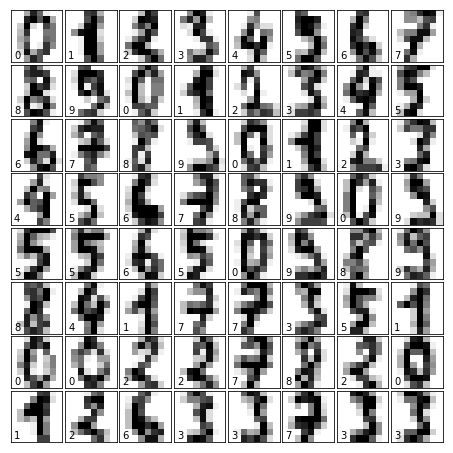

```python
import matplotlib.pyplot as plt

# Figure size (width, height) in inches
fig = plt.figure(figsize=(6, 6))

# Adjust the subplots
fig.subplots_adjust(left=0, right=1, bottom=0, top=1, hspace=0.05, wspace=0.05)

# For each of the 64 images
for i in range(64):
    # Initialize the subplots: add a subplot in the grid of 8 by 8, at the i+1-th position
    ax = fig.add_subplot(8, 8, i + 1, xticks=[], yticks=[])
    # Display an image at the i-th position
    ax.imshow(digits.images[i], cmap=plt.cm.binary, interpolation='nearest')
    # label the image with the target value
    ax.text(0, 7, str(digits.target[i]))

# Show the plot
plt.show()
```

You can also visualize the target labels with an image, just like this:

**Execute the code in the cell below**

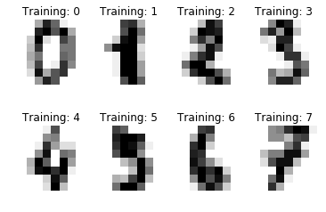

```python
# Import matplotlib
import matplotlib.pyplot as plt

# Join the images and target labels in a list
images_and_labels = list(zip(digits.images, digits.target))

# for every element in the list
for index, (image, label) in enumerate(images_and_labels[:8]):
    # initialize a subplot of 2X6 at the i+1-th position
    plt.subplot(2, 4, index + 1)
    # Don't plot any axes
    plt.axis('off')
    # Display images in all subplots
    plt.imshow(image, cmap=plt.cm.gray_r, interpolation='nearest')
    # Add a title to each subplot
    plt.title('Training: ' + str(label))

# Show the plot
plt.show()
```

Note that in this case, after you have imported `matplotlib.pyplot`, you zip the two `numpy` arrays together and save it into a variable called `images_and_labels`. You will see now that this list contains tuples of each time an instance of `digits.images` and a corresponding `digits.target` value.

Then, for the first eight elements of `images_and_labels` - note that the index starts at 0 -, you initialize subplots in a grid of 2 by 4 at each position. Then turn off the plotting of the axes and display images in all the subplots with a color map `plt.cm.gray_r` (which returns all grey colors) and the interpolation method used is `nearest`. Give a title to each subplot, and show it.

### Data Normalization

We do some preprocessing of the data. You can standardize the `digits` data by, for example, making use of the `scale()` method.

**Execute the code in the cell below**

```python
# Import scale from sklearn
from sklearn.preprocessing import scale

# Apply `scale()` to the `digits` data
data = scale(digits.data)
```

By scaling the data, you *shift the distribution of each attribute to have a mean of zero and a standard deviation of one* (unit variance).

### Splitting Your Data Into Training And Test Sets

In order to assess the model’s performance later, we need to divide the data set into two parts: a **training set** and a **test set**. The first is used to train the system, while the second is used to evaluate the learned or trained system.

In practice, the division of the data set into a test and a training sets is disjoint:

- take 3/4 of your original data set as the training set,
- let the 1/4 that remains will compose the test set.

**Execute the code in the cell below to partition the data**

```python
# Import `train_test_split`
from sklearn.cross_validation import train_test_split

# Split the `digits` data into training and test sets
X_train, X_test, y_train, y_test, images_train, images_test = train_test_split(data, digits.target, digits.images, test_size=0.25, random_state=23)
# random_state set to 23 is the random seed we use in this case

# Number of training features
n_samples, n_features = X_train.shape

# Print out `n_samples`
print(n_samples)

# Print out `n_features`
print(n_features)

# Number of Training labels
n_digits = len(np.unique(y_train))

# Inspect `y_train`
print(len(y_train))

#Number of samples in training set X_train
print("Samples in X_test",len(X_test))
```

```
1347
64
1347
Samples in X_test 450
```

- **How many samples are in the training set `X_train`?**

1347

- **How many samples are in the testing set `X_test`?**

450

- **How many *features* are considered for every sample?**

64

## SVM

We now use the Support Vector Machines (SVM) implementation from `scikit-learn` to train a **classifier**

**Execute the code in the cell below to train an SVM classifier**

```python
# Support Vector Machines

# Import `train_test_split`
from sklearn.cross_validation import train_test_split

# Split the data into training and test sets
X_train, X_test, y_train, y_test, images_train, images_test = train_test_split(digits.data, digits.target, digits.images, test_size=0.25, random_state=42)

# Import the `svm` model
from sklearn import svm

# Create the SVC model
svc_model = svm.SVC(gamma=0.001, C=100., kernel='linear')

# Fit the data to the SVC model
svc_model.fit(X_train, y_train)
```

```
SVC(C=100.0, cache_size=200, class_weight=None, coef0=0.0,
  decision_function_shape='ovr', degree=3, gamma=0.001, kernel='linear',
  max_iter=-1, probability=False, random_state=None, shrinking=True,
  tol=0.001, verbose=False)
```

We make use of `X_train` and `y_train` to fit the data to the [SVC model](http://scikit-learn.org/stable/modules/generated/sklearn.svm.SVC.html).

Note also that in this example, you set the value of `gamma` ($\gamma$) manually. It is possible to automatically find good values for the parameters by using techniques such as *grid search* and *cross validation*.

Notice that in the SVM classifier, the penalty parameter `C` of the error term is specified at 100. Also, notice that the **kernel** has been explicitly specified as a *linear one*.

We can now make some predictions on the `X_test` using the SVM model, and compare with the actual labels stored in `y_test`.

**Execute the code in the cell below**

```python
# Predict the label of `X_test`
print(svc_model.predict(X_test))

# Print `y_test` to check the results
print(y_test)
```

```
[6 9 3 7 2 1 5 2 5 2 1 9 4 0 4 2 3 7 8 8 4 3 9 7 5 6 3 5 6 3 4 9 1 4 4 6 9
 4 7 6 6 9 1 3 6 1 3 0 6 5 5 1 3 5 6 0 9 0 0 1 0 4 5 2 4 5 7 0 7 5 9 5 5 4
 7 0 4 5 5 9 9 0 2 3 8 0 6 4 4 9 1 2 8 3 5 2 9 0 4 4 4 3 5 3 1 3 5 9 4 2 7
 7 4 4 1 9 2 7 8 7 2 6 9 4 0 7 2 7 5 8 7 5 7 9 0 6 6 4 2 8 0 9 4 6 9 9 6 9
 0 5 5 6 6 0 6 4 3 9 3 7 7 2 9 0 4 5 3 6 5 9 9 8 4 2 1 3 7 7 2 2 3 9 8 0 3
 2 2 5 6 9 9 4 1 5 4 2 3 6 4 8 5 9 5 7 8 9 4 8 1 5 4 4 9 6 1 8 6 0 4 5 2 7
 1 6 4 5 6 0 3 2 3 6 7 1 5 1 4 7 6 5 8 5 5 1 6 2 8 8 9 9 7 6 2 2 2 3 4 8 8
 3 6 0 9 7 7 0 1 0 4 5 1 5 3 6 0 4 1 0 0 3 6 5 9 7 3 5 5 9 9 8 5 3 3 2 0 5
 8 3 4 0 2 4 6 4 3 4 5 0 5 2 1 3 1 4 1 1 7 0 1 5 2 1 2 8 7 0 6 4 8 8 5 1 8
 4 5 8 7 9 8 5 0 6 2 0 7 9 8 9 5 2 7 7 1 8 7 4 3 8 9 5 6 0 0 3 0 5 0 0 4 1
 2 8 4 5 9 6 3 1 8 8 4 2 3 8 9 8 8 5 0 6 3 3 7 1 6 4 1 2 1 1 6 4 7 4 8 3 4
 0 5 1 9 4 5 7 6 3 7 0 5 9 7 5 9 7 4 2 1 9 0 7 5 2 3 6 3 9 6 9 5 0 1 5 5 8
 3 3 6 2 6 5]
[6 9 3 7 2 1 5 2 5 2 1 9 4 0 4 2 3 7 8 8 4 3 9 7 5 6 3 5 6 3 4 9 1 4 4 6 9
 4 7 6 6 9 1 3 6 1 3 0 6 5 5 1 9 5 6 0 9 0 0 1 0 4 5 2 4 5 7 0 7 5 9 5 5 4
 7 0 4 5 5 9 9 0 2 3 8 0 6 4 4 9 1 2 8 3 5 2 9 0 4 4 4 3 5 3 1 3 5 9 4 2 7
 7 4 4 1 9 2 7 8 7 2 6 9 4 0 7 2 7 5 8 7 5 7 7 0 6 6 4 2 8 0 9 4 6 9 9 6 9
 0 3 5 6 6 0 6 4 3 9 3 9 7 2 9 0 4 5 3 6 5 9 9 8 4 2 1 3 7 7 2 2 3 9 8 0 3
 2 2 5 6 9 9 4 1 5 4 2 3 6 4 8 5 9 5 7 8 9 4 8 1 5 4 4 9 6 1 8 6 0 4 5 2 7
 4 6 4 5 6 0 3 2 3 6 7 1 5 1 4 7 6 8 8 5 5 1 6 2 8 8 9 9 7 6 2 2 2 3 4 8 8
 3 6 0 9 7 7 0 1 0 4 5 1 5 3 6 0 4 1 0 0 3 6 5 9 7 3 5 5 9 9 8 5 3 3 2 0 5
 8 3 4 0 2 4 6 4 3 4 5 0 5 2 1 3 1 4 1 1 7 0 1 5 2 1 2 8 7 0 6 4 8 8 5 1 8
 4 5 8 7 9 8 5 0 6 2 0 7 9 8 9 5 2 7 7 1 8 7 4 3 8 3 5 6 0 0 3 0 5 0 0 4 1
 2 8 4 5 9 6 3 1 8 8 4 2 3 8 9 8 8 5 0 6 3 3 7 1 6 4 1 2 1 1 6 4 7 4 8 3 4
 0 5 1 9 4 5 7 6 3 7 0 5 9 7 5 9 7 4 2 1 9 0 7 5 3 3 6 3 9 6 9 5 0 1 5 5 8
 3 3 6 2 6 5]
```

You can also visualize the images and their predicted labels. This plot is very similar to the plot that we made when exploring the data.

**Execute the code in the cell below**

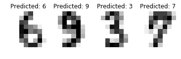

```python
# Import matplotlib
import matplotlib.pyplot as plt

# Assign the predicted values to `predicted`
predicted = svc_model.predict(X_test)

# Zip together the `images_test` and `predicted` values in `images_and_predictions`
images_and_predictions = list(zip(images_test, predicted))

# For the first 4 elements in `images_and_predictions`
for index, (image, prediction) in enumerate(images_and_predictions[:4]):
    # Initialize subplots in a grid of 1 by 4 at positions i+1
    plt.subplot(1, 4, index + 1)
    # Don't show axes
    plt.axis('off')
    # Display images in all subplots in the grid
    plt.imshow(image, cmap=plt.cm.gray_r, interpolation='nearest')
    # Add a title to the plot
    plt.title('Predicted: ' + str(prediction))

# Show the plot
plt.show()
```

This time we zip together the images and the predicted values and only take the first 4 elements of `images_and_predictions`.

We can also use `scikit-learn` to run some *metrics* on our classifier.

**Execute the code in the cell below**

```python
# Import `metrics`
from sklearn import metrics

# Print the classification report of `y_test` and `predicted`
print(metrics.classification_report(y_test, predicted))

# Print the confusion matrix of `y_test` and `predicted`
print(metrics.confusion_matrix(y_test, predicted))
```

```
             precision    recall  f1-score   support

          0       1.00      1.00      1.00        43
          1       0.97      1.00      0.99        37
          2       0.97      1.00      0.99        38
          3       0.98      0.93      0.96        46
          4       1.00      0.98      0.99        55
          5       0.97      1.00      0.98        59
          6       1.00      1.00      1.00        45
          7       0.98      0.98      0.98        41
          8       1.00      0.97      0.99        38
          9       0.96      0.96      0.96        48

avg / total       0.98      0.98      0.98       450

[[43  0  0  0  0  0  0  0  0  0]
 [ 0 37  0  0  0  0  0  0  0  0]
 [ 0  0 38  0  0  0  0  0  0  0]
 [ 0  0  1 43  0  1  0  0  0  1]
 [ 0  1  0  0 54  0  0  0  0  0]
 [ 0  0  0  0  0 59  0  0  0  0]
 [ 0  0  0  0  0  0 45  0  0  0]
 [ 0  0  0  0  0  0  0 40  0  1]
 [ 0  0  0  0  0  1  0  0 37  0]
 [ 0  0  0  1  0  0  0  1  0 46]]
```

**Metrics**

- Define *precision*, *recall*, and *f1-score*

**Precision** - performance metric that is related to true positive and true negative rates. How many selected items are relevant.

**Recall** - synonymous to the true positive rate. How many relevant items are selected.

**F1-Score** - measure that combines precision and recall or the harmonic mean of both. $F1 = 2 \frac{PRE x REC}{PRE + REC}$

You can find information about these metrics on your textbook in Chapter 6.

**Create a second model**

- Create a second SVM model called `svc_2` with the option `kernel='rbf'` and the same values for the parameters `gamma` and `C`
- Report the results of this new model. Is it better than the first SVM model?  
  It is better than the first SVM model.

```python
svc_2 = svm.SVC(gamma=0.001, C=100., kernel='rbf')
svc_2.fit(X_train, y_train)

# Assign the predicted values to `predicted`
predicted = svc_2.predict(X_test)

# Print the classification report of `y_test` and `predicted`
print(metrics.classification_report(y_test, predicted))

# Print the confusion matrix of `y_test` and `predicted`
print(metrics.confusion_matrix(y_test, predicted))
```

```
             precision    recall  f1-score   support

          0       1.00      1.00      1.00        43
          1       1.00      1.00      1.00        37
          2       1.00      1.00      1.00        38
          3       1.00      0.96      0.98        46
          4       1.00      1.00      1.00        55
          5       0.98      1.00      0.99        59
          6       1.00      1.00      1.00        45
          7       0.98      0.98      0.98        41
          8       0.97      1.00      0.99        38
          9       0.98      0.98      0.98        48

avg / total       0.99      0.99      0.99       450

[[43  0  0  0  0  0  0  0  0  0]
 [ 0 37  0  0  0  0  0  0  0  0]
 [ 0  0 38  0  0  0  0  0  0  0]
 [ 0  0  0 44  0  1  0  0  1  0]
 [ 0  0  0  0 55  0  0  0  0  0]
 [ 0  0  0  0  0 59  0  0  0  0]
 [ 0  0  0  0  0  0 45  0  0  0]
 [ 0  0  0  0  0  0  0 40  0  1]
 [ 0  0  0  0  0  0  0  0 38  0]
 [ 0  0  0  0  0  0  0  1  0 47]]
```

**Logistic Regression**

- Create a logistic regression model for this same problem. Name your classifier `log_model`, and use the `scikit-learn` implementation of logistic regression `from sklearn.linear_model import LogisticRegression`

```python
from sklearn.linear_model import LogisticRegression

log_model = LogisticRegression(C=100.0,random_state=1)
log_model.fit(X_train,y_train)
```

```
LogisticRegression(C=100.0, class_weight=None, dual=False, fit_intercept=True,
          intercept_scaling=1, max_iter=100, multi_class='ovr', n_jobs=1,
          penalty='l2', random_state=1, solver='liblinear', tol=0.0001,
          verbose=0, warm_start=False)
```

- Run predictions using this new model and save them in an object called `predicted_log`

```python
# Assign the predicted values to `predicted_log`
predicted_log = log_model.predict(X_test)
predicted_log
```

```
array([6, 9, 3, 7, 2, 1, 5, 2, 5, 2, 1, 8, 4, 0, 4, 2, 3, 7, 8, 8, 4, 3, 9,
       7, 5, 6, 3, 5, 6, 3, 4, 9, 1, 4, 4, 6, 9, 4, 7, 6, 6, 9, 1, 3, 6, 1,
       3, 0, 6, 5, 5, 1, 9, 5, 6, 0, 9, 0, 0, 1, 0, 4, 5, 2, 4, 5, 7, 0, 7,
       5, 9, 5, 5, 4, 7, 0, 4, 5, 5, 0, 9, 0, 2, 3, 8, 0, 6, 4, 4, 9, 1, 2,
       8, 3, 9, 2, 9, 0, 4, 4, 4, 3, 5, 3, 1, 3, 5, 9, 4, 2, 7, 7, 4, 4, 1,
       9, 2, 7, 8, 7, 2, 6, 9, 4, 0, 7, 2, 7, 5, 8, 7, 5, 7, 9, 0, 6, 6, 4,
       2, 8, 0, 9, 4, 6, 9, 9, 6, 9, 0, 5, 5, 6, 6, 0, 6, 4, 3, 9, 3, 8, 7,
       2, 9, 0, 4, 5, 3, 6, 5, 8, 9, 8, 4, 2, 1, 3, 7, 7, 2, 2, 3, 9, 8, 0,
       3, 2, 2, 5, 6, 9, 9, 4, 1, 2, 4, 2, 3, 6, 4, 8, 5, 9, 5, 7, 8, 9, 4,
       8, 1, 5, 4, 4, 9, 6, 1, 8, 6, 0, 4, 5, 2, 7, 1, 6, 4, 5, 6, 0, 3, 2,
       3, 6, 7, 1, 9, 1, 4, 7, 6, 5, 8, 5, 5, 1, 5, 2, 8, 8, 9, 9, 7, 6, 2,
       2, 2, 3, 4, 8, 8, 3, 6, 0, 8, 7, 7, 0, 1, 0, 4, 5, 8, 5, 3, 6, 0, 4,
       1, 0, 0, 3, 6, 5, 9, 7, 3, 5, 5, 9, 9, 8, 5, 3, 3, 2, 0, 5, 8, 3, 4,
       0, 2, 4, 6, 4, 3, 4, 5, 0, 5, 2, 1, 3, 1, 4, 1, 1, 7, 0, 1, 5, 2, 1,
       2, 8, 7, 0, 6, 4, 8, 8, 5, 1, 8, 4, 5, 8, 7, 9, 8, 8, 0, 6, 2, 0, 7,
       9, 1, 9, 5, 2, 7, 7, 1, 8, 7, 4, 3, 8, 3, 5, 6, 0, 0, 3, 0, 5, 0, 0,
       4, 1, 2, 8, 4, 5, 9, 6, 3, 1, 8, 8, 4, 2, 3, 8, 9, 8, 8, 5, 0, 6, 3,
       3, 7, 1, 6, 4, 1, 2, 1, 1, 6, 4, 7, 4, 8, 3, 4, 0, 5, 1, 9, 4, 5, 7,
       6, 3, 7, 0, 5, 9, 7, 5, 9, 7, 4, 2, 1, 9, 0, 7, 5, 8, 3, 6, 3, 9, 6,
       9, 5, 0, 1, 5, 5, 8, 3, 3, 6, 2, 6, 5])
```

- Import `metrics` from `sklearn` and check how well the logistic regression models performed. Is it better than the SVM models studied before? **It is not better than the first nor the tuned second SVM models**

```python
# Import `metrics`
from sklearn import metrics

# Print the classification report of `y_test` and `predicted_log`
print(metrics.classification_report(y_test, predicted_log))

# Print the confusion matrix of `y_test` and `predicted_log`
print(metrics.confusion_matrix(y_test, predicted_log))
```

```
             precision    recall  f1-score   support

          0       0.98      1.00      0.99        43
          1       0.95      0.97      0.96        37
          2       0.97      1.00      0.99        38
          3       1.00      0.96      0.98        46
          4       1.00      0.98      0.99        55
          5       0.95      0.93      0.94        59
          6       1.00      0.98      0.99        45
          7       1.00      0.98      0.99        41
          8       0.84      0.95      0.89        38
          9       0.93      0.90      0.91        48

avg / total       0.96      0.96      0.96       450

[[43  0  0  0  0  0  0  0  0  0]
 [ 0 36  0  0  0  0  0  0  1  0]
 [ 0  0 38  0  0  0  0  0  0  0]
 [ 0  0  0 44  0  1  0  0  1  0]
 [ 0  1  0  0 54  0  0  0  0  0]
 [ 0  0  1  0  0 55  0  0  1  2]
 [ 0  0  0  0  0  1 44  0  0  0]
 [ 0  0  0  0  0  0  0 40  0  1]
 [ 0  1  0  0  0  1  0  0 36  0]
 [ 1  0  0  0  0  0  0  0  4 43]]
```

**Decision Trees**

- Create a decision tree classifier using the implementation from `scikit-learn` and the option `max_depth=10`

```python
from sklearn.tree import DecisionTreeClassifier

tree = DecisionTreeClassifier(criterion='gini',max_depth=10,random_state=1)
tree.fit(X_train,y_train)
```

```
DecisionTreeClassifier(class_weight=None, criterion='gini', max_depth=10,
            max_features=None, max_leaf_nodes=None,
            min_impurity_decrease=0.0, min_impurity_split=None,
            min_samples_leaf=1, min_samples_split=2,
            min_weight_fraction_leaf=0.0, presort=False, random_state=1,
            splitter='best')
```

- Run predictions using this decision tree model and save them in an object called `predicted_tree`

```python
# Assign the predicted values to `predicted_tree`

predicted_tree=tree.predict(X_test)
predicted_tree
```

```
array([6, 9, 3, 7, 2, 1, 5, 3, 5, 7, 2, 9, 4, 0, 4, 2, 3, 7, 8, 8, 4, 3, 9,
       7, 5, 6, 3, 5, 6, 8, 4, 9, 1, 4, 4, 6, 9, 4, 7, 6, 6, 9, 1, 3, 6, 1,
       3, 0, 6, 5, 5, 1, 5, 5, 6, 0, 3, 0, 0, 8, 5, 4, 5, 2, 6, 5, 7, 0, 7,
       5, 9, 5, 5, 4, 7, 0, 4, 5, 5, 9, 9, 0, 2, 3, 8, 0, 6, 4, 4, 1, 1, 2,
       8, 3, 5, 2, 9, 4, 4, 7, 4, 3, 5, 3, 1, 9, 5, 9, 4, 2, 7, 7, 4, 4, 1,
       9, 2, 7, 8, 7, 2, 6, 9, 4, 0, 7, 2, 7, 5, 9, 7, 5, 7, 3, 0, 6, 6, 4,
       2, 8, 0, 9, 4, 6, 9, 9, 6, 9, 0, 5, 5, 6, 6, 0, 6, 4, 3, 9, 3, 4, 7,
       2, 9, 0, 4, 5, 8, 6, 8, 9, 9, 8, 4, 2, 1, 8, 7, 7, 2, 2, 3, 9, 2, 0,
       3, 8, 2, 5, 6, 9, 9, 4, 1, 5, 4, 3, 3, 6, 4, 1, 5, 9, 5, 7, 8, 9, 4,
       8, 1, 5, 4, 4, 9, 6, 1, 8, 6, 0, 4, 5, 2, 7, 4, 6, 4, 5, 6, 4, 3, 2,
       3, 6, 7, 1, 5, 1, 4, 7, 6, 9, 8, 5, 5, 1, 5, 2, 8, 1, 7, 9, 7, 4, 2,
       3, 2, 3, 5, 8, 4, 3, 6, 0, 9, 7, 7, 0, 1, 0, 4, 5, 8, 5, 3, 6, 0, 4,
       1, 0, 4, 3, 6, 5, 9, 7, 7, 7, 5, 9, 9, 4, 5, 3, 3, 2, 0, 5, 8, 3, 4,
       0, 2, 7, 6, 4, 3, 4, 5, 0, 5, 2, 1, 3, 1, 4, 3, 1, 7, 0, 1, 5, 2, 1,
       8, 8, 7, 0, 6, 4, 8, 4, 5, 1, 8, 4, 1, 2, 3, 9, 8, 6, 0, 6, 2, 0, 7,
       9, 1, 9, 5, 2, 7, 7, 1, 8, 7, 4, 3, 1, 8, 3, 6, 0, 0, 3, 0, 5, 0, 0,
       4, 1, 2, 8, 4, 5, 9, 6, 3, 8, 8, 8, 4, 2, 3, 9, 9, 8, 8, 4, 0, 6, 3,
       3, 7, 1, 6, 4, 1, 2, 1, 1, 6, 4, 7, 4, 8, 3, 4, 0, 5, 9, 9, 4, 5, 7,
       6, 3, 1, 0, 5, 9, 7, 5, 9, 7, 4, 2, 1, 9, 0, 7, 5, 3, 3, 6, 3, 3, 6,
       9, 5, 0, 1, 5, 5, 8, 1, 3, 6, 2, 6, 5])
```

- Import `metrics` from `sklearn` and check how well the decision tree model performed. Is it better than the SVM models studied before? No it is not better in fact it is actually the worse of all the models.

```python
# Import `metrics`
from sklearn import metrics

# Print the classification report of `y_test` and `predicted_tree`
print(metrics.classification_report(y_test, predicted_tree))

# Print the confusion matrix of `y_test` and `predicted_tree`
print(metrics.confusion_matrix(y_test, predicted_tree))
```

```
             precision    recall  f1-score   support

          0       1.00      0.91      0.95        43
          1       0.79      0.84      0.82        37
          2       0.91      0.84      0.88        38
          3       0.81      0.83      0.82        46
          4       0.85      0.93      0.89        55
          5       0.91      0.90      0.91        59
          6       0.96      0.96      0.96        45
          7       0.86      0.93      0.89        41
          8       0.72      0.68      0.70        38
          9       0.89      0.88      0.88        48

avg / total       0.88      0.87      0.87       450

[[39  0  0  0  3  1  0  0  0  0]
 [ 0 31  1  1  0  0  0  0  3  1]
 [ 0  0 32  3  0  0  0  1  2  0]
 [ 0  1  0 38  0  1  0  1  4  1]
 [ 0  0  0  0 51  1  1  2  0  0]
 [ 0  1  0  1  1 53  1  1  1  0]
 [ 0  0  0  0  1  1 43  0  0  0]
 [ 0  1  0  2  0  0  0 38  0  0]
 [ 0  4  2  0  3  0  0  0 26  3]
 [ 0  1  0  2  1  1  0  1  0 42]]
```